# **Semiconductor Defect Detection**

# **[Exploratory Data Analysis]**

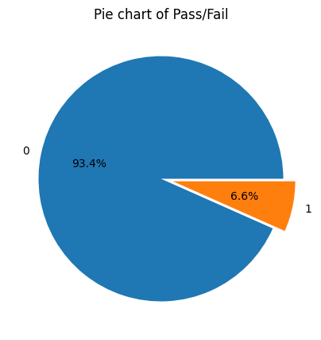

```python
plt.figure(figsize=(5,5))
semi['Pass/Fail'].value_counts().plot.pie(explode=[0, 0.1], autopct='%1.1f%%')
plt.title('Pie chart of Pass/Fail')
plt.ylabel('')
plt.show()
```

```python
semi.dtypes
```

```
Time          object
0            float64
1            float64
2            float64
3            float64
              ...
586          float64
587          float64
588          float64
589          float64
Pass/Fail      int64
Length: 592, dtype: object
```

**KMeans clustering with 3 clusters**

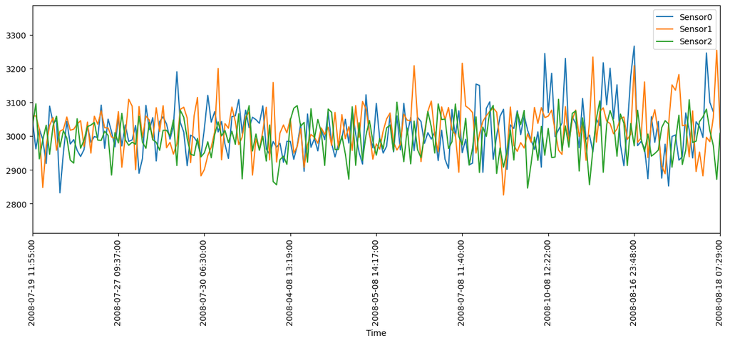

```python
features_a = semi.loc[:,['Time']]
features = semi.drop(['Time','Pass/Fail'], axis=1)

kmeans = KMeans(n_clusters=3, random_state=0).fit(features)

features['cluster'] = kmeans.labels_

features['cluster'].replace({0: 'Sensor0', 1: 'Sensor1', 2: 'Sensor2'}, inplace=True)
features = pd.concat([features_a, features], axis=1)

fig, ax = plt.subplots(figsize=(15,5))
for key, grp in features.groupby(['cluster']):
    ax = grp.plot(ax=ax, kind='line', x='Time', y='0', label=key)
plt.legend(loc='best')
plt.xticks(rotation=90)
plt.xlim(0,200)
plt.show()
```

**Re-arrange the features & drop 'Time'**

```python
semi_a = semi.loc[:,['Time','Pass/Fail']]
semi= semi.drop(['Time', 'Pass/Fail'], axis=1).add_prefix('V')
```

```python
semi = pd.concat([semi_a, semi], axis=1)
```

```python
semi.drop(['Time'], axis=1, inplace=True)
```

```python
semi.head()
```

|  | Pass/Fail | V0 | V1 | V2 | V3 | V4 | V5 | V6 | V7 | V8 | ... | V580 | V581 | V582 | V583 | V584 | V585 | V586 | V587 | V588 | V589 |
| --- | --- | --- | --- | --- | --- | --- | --- | --- | --- | --- | --- | --- | --- | --- | --- | --- | --- | --- | --- | --- | --- |
| 0 | 0 | 3030.93 | 2564.00 | 2187.7333 | 1411.1265 | 1.3602 | 100.0 | 97.6133 | 0.1242 | 1.5005 | ... | 0.005396 | 97.934373 | 0.5005 | 0.0118 | 0.0035 | 2.3630 | 0.021458 | 0.016475 | 0.005283 | 99.670066 |
| 1 | 0 | 3095.78 | 2465.14 | 2230.4222 | 1463.6606 | 0.8294 | 100.0 | 102.3433 | 0.1247 | 1.4966 | ... | 0.006000 | 208.204500 | 0.5019 | 0.0223 | 0.0055 | 4.4447 | 0.009600 | 0.020100 | 0.006000 | 208.204500 |
| 2 | 1 | 2932.61 | 2559.94 | 2186.4111 | 1698.0172 | 1.5102 | 100.0 | 95.4878 | 0.1241 | 1.4436 | ... | 0.014800 | 82.860200 | 0.4958 | 0.0157 | 0.0039 | 3.1745 | 0.058400 | 0.048400 | 0.014800 | 82.860200 |
| 3 | 0 | 2988.72 | 2479.90 | 2199.0333 | 909.7926 | 1.3204 | 100.0 | 104.2367 | 0.1217 | 1.4882 | ... | 0.004400 | 73.843200 | 0.4990 | 0.0103 | 0.0025 | 2.0544 | 0.020200 | 0.014900 | 0.004400 | 73.843200 |
| 4 | 0 | 3032.24 | 2502.87 | 2233.3667 | 1326.5200 | 1.5334 | 100.0 | 100.3967 | 0.1235 | 1.5031 | ... | 0.005396 | 97.934373 | 0.4800 | 0.4766 | 0.1045 | 99.3032 | 0.020200 | 0.014900 | 0.004400 | 73.843200 |

5 rows × 591 columns

```python
semi_statistic = semi.describe().transpose()
semi_statistic
```

|  | count | mean | std | min | 25% | 50% | 75% | max |
| --- | --- | --- | --- | --- | --- | --- | --- | --- |
| Pass/Fail | 1567.0 | 0.066369 | 0.249005 | 0.0000 | 0.00000 | 0.0000 | 0.00000 | 1.0000 |
| V0 | 1567.0 | 3014.452896 | 73.480613 | 2743.2400 | 2966.66500 | 3011.8400 | 3056.54000 | 3356.3500 |
| V1 | 1567.0 | 2495.850231 | 80.227793 | 2158.7500 | 2452.88500 | 2498.9100 | 2538.74500 | 2846.4400 |
| V2 | 1567.0 | 2200.547318 | 29.380932 | 2060.6600 | 2181.09995 | 2200.9556 | 2218.05550 | 2315.2667 |
| V3 | 1567.0 | 1396.376627 | 439.712852 | 0.0000 | 1083.88580 | 1287.3538 | 1590.16990 | 3715.0417 |
| ... | ... | ... | ... | ... | ... | ... | ... | ... |
| V585 | 1567.0 | 3.067826 | 3.576891 | 1.1975 | 2.30650 | 2.7577 | 3.29495 | 99.3032 |
| V586 | 1567.0 | 0.021458 | 0.012354 | -0.0169 | 0.01345 | 0.0205 | 0.02760 | 0.1028 |
| V587 | 1567.0 | 0.016475 | 0.008805 | 0.0032 | 0.01060 | 0.0148 | 0.02030 | 0.0799 |
| V588 | 1567.0 | 0.005283 | 0.002866 | 0.0010 | 0.00330 | 0.0046 | 0.00640 | 0.0286 |
| V589 | 1567.0 | 99.670066 | 93.861936 | 0.0000 | 44.36860 | 72.0230 | 114.74970 | 737.3048 |

591 rows × 8 columns

**Remove Normal Sensors**

- Find the sensors that have 0< std <0.005
- ['V5' 'V13' 'V42' 'V49' 'V52' 'V57' 'V69' 'V85' 'V92' 'V93' 'V94' 'V95' 'V97' 'V100' 'V101' 'V103' 'V104' 'V105' 'V106' 'V114' 'V131' 'V141' 'V143' 'V149' 'V178' 'V179' 'V186' 'V189' 'V190' 'V191' 'V192' 'V193' 'V194' 'V219' 'V220' 'V226' 'V229' 'V230' 'V231' 'V232' 'V233' 'V234' 'V235' 'V236' 'V237' 'V238' 'V239' 'V240' 'V241' 'V242' 'V243' 'V256' 'V257' 'V258' 'V259' 'V260' 'V261' 'V262' 'V263' 'V264' 'V265' 'V266' 'V276' 'V278' 'V284' 'V288' 'V292' 'V313' 'V314' 'V315' 'V322' 'V325' 'V326' 'V327' 'V328' 'V329' 'V330' 'V357' 'V358' 'V364' 'V365' 'V366' 'V367' 'V368' 'V369' 'V370' 'V371' 'V372' 'V373' 'V374' 'V375' 'V376' 'V377' 'V378' 'V379' 'V380' 'V381' 'V387' 'V392' 'V394' 'V395' 'V396' 'V397' 'V398' 'V399' 'V400' 'V401' 'V402' 'V403' 'V404' 'V414' 'V422' 'V449' 'V450' 'V451' 'V458' 'V461' 'V462' 'V463' 'V464' 'V465' 'V466' 'V481' 'V498' 'V501' 'V502' 'V503' 'V504' 'V505' 'V506' 'V507' 'V508' 'V509' 'V512' 'V513' 'V514' 'V515' 'V528' 'V529' 'V530' 'V531' 'V532' 'V533' 'V534' 'V535' 'V536' 'V537' 'V538' 'V542' 'V543' 'V544' 'V580' 'V582' 'V584' 'V588']

```python
semi_remove = semi_statistic[(semi_statistic['std'] >= 0) & (semi_statistic['std'] < 0.005)].index
```

```python
semi_remove
```

```
Index(['V5', 'V13', 'V42', 'V49', 'V52', 'V57', 'V69', 'V85', 'V92', 'V93',
       ...
       'V536', 'V537', 'V538', 'V542', 'V543', 'V544', 'V580', 'V582', 'V584',
       'V588'],
      dtype='object', length=155)
```

```python
semi.drop(semi_remove, axis=1, inplace=True)
```

```python
semi.head()
```

|  | Pass/Fail | V0 | V1 | V2 | V3 | V4 | V6 | V7 | V8 | V9 | ... | V576 | V577 | V578 | V579 | V581 | V583 | V585 | V586 | V587 | V589 |
| --- | --- | --- | --- | --- | --- | --- | --- | --- | --- | --- | --- | --- | --- | --- | --- | --- | --- | --- | --- | --- | --- |
| 0 | 0 | 3030.93 | 2564.00 | 2187.7333 | 1411.1265 | 1.3602 | 97.6133 | 0.1242 | 1.5005 | 0.0162 | ... | 1.6765 | 14.9509 | 0.021615 | 0.016829 | 97.934373 | 0.0118 | 2.3630 | 0.021458 | 0.016475 | 99.670066 |
| 1 | 0 | 3095.78 | 2465.14 | 2230.4222 | 1463.6606 | 0.8294 | 102.3433 | 0.1247 | 1.4966 | -0.0005 | ... | 1.1065 | 10.9003 | 0.009600 | 0.020100 | 208.204500 | 0.0223 | 4.4447 | 0.009600 | 0.020100 | 208.204500 |
| 2 | 1 | 2932.61 | 2559.94 | 2186.4111 | 1698.0172 | 1.5102 | 95.4878 | 0.1241 | 1.4436 | 0.0041 | ... | 2.0952 | 9.2721 | 0.058400 | 0.048400 | 82.860200 | 0.0157 | 3.1745 | 0.058400 | 0.048400 | 82.860200 |
| 3 | 0 | 2988.72 | 2479.90 | 2199.0333 | 909.7926 | 1.3204 | 104.2367 | 0.1217 | 1.4882 | -0.0124 | ... | 1.7585 | 8.5831 | 0.020200 | 0.014900 | 73.843200 | 0.0103 | 2.0544 | 0.020200 | 0.014900 | 73.843200 |
| 4 | 0 | 3032.24 | 2502.87 | 2233.3667 | 1326.5200 | 1.5334 | 100.3967 | 0.1235 | 1.5031 | -0.0031 | ... | 1.6597 | 10.9698 | 0.021615 | 0.016829 | 97.934373 | 0.4766 | 99.3032 | 0.020200 | 0.014900 | 73.843200 |

5 rows × 436 columns

```python
correlation_matrix = semi.corr()["Pass/Fail"]
correlation_matrix = abs(correlation_matrix)
correlation_matrix.drop("Pass/Fail", inplace=True)  # drop "Pass/Fail" row
```

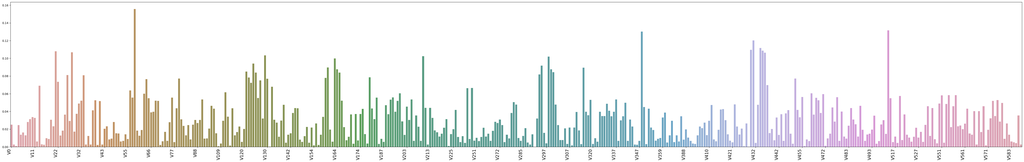

```python
plt.figure(figsize=(50, 8))
ax.set_ylim([0,0.2])
sns.barplot(x=correlation_matrix.index, y=correlation_matrix.values,
            orient='v', saturation=0.5)
plt.xticks(rotation=90, ha='right', fontsize = 15)
plt.xticks(np.arange(0, len(correlation_matrix.index), 10)) # set x-tick frequency to 10
plt.tight_layout()
plt.show()
```

```python
s_corr = semi.corr()['Pass/Fail']
s_corr
```

```
Pass/Fail    1.000000
V0          -0.025141
V1          -0.002603
V2          -0.000957
V3          -0.024623
               ...
V583         0.005981
V585         0.005034
V586         0.004156
V587         0.035391
V589        -0.002653
Name: Pass/Fail, Length: 436, dtype: float64
```

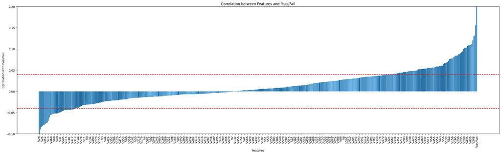

```python
s_corr_sorted = s_corr.sort_values()

fig, ax = plt.subplots(figsize=(30, 8))
ax.set_ylim([-0.1,0.2])
ax.bar(s_corr_sorted.index, s_corr_sorted.values)

ax.set_xlabel('Features')
ax.set_ylabel('Correlation with Pass/Fail')
ax.set_title('Correlation between Features and Pass/Fail')

ax.axhline(y=-0.04, color='r', linestyle='--')
ax.axhline(y=0.04, color='r', linestyle='--')

plt.xticks(rotation=90)
plt.xticks(np.arange(0, len(s_corr_sorted.index), 3))

plt.show()
```

# **[Feature Selection and Normalization]**

- Total 121 featrues

```python
s_corr_matrix = s_corr.loc[np.abs(s_corr) > 0.04]
```

```python
s_corr_matrix = s_corr_matrix.reset_index()
s_corr_matrix = s_corr_matrix.rename(columns={"index": "Sensors"})
s_corr_matrix = s_corr_matrix.drop(0)
```

```python
s_corr_matrix
```

|  | Sensors | Pass/Fail |
| --- | --- | --- |
| 1 | V14 | -0.068975 |
| 2 | V21 | 0.107997 |
| 3 | V22 | -0.073380 |
| 4 | V26 | -0.081146 |
| 5 | V28 | -0.106767 |
| ... | ... | ... |
| 117 | V567 | 0.040359 |
| 118 | V569 | 0.045828 |
| 119 | V573 | -0.051873 |
| 120 | V575 | -0.052731 |
| 121 | V577 | -0.049633 |

121 rows × 2 columns

```python
sensors = s_corr_matrix['Sensors']
```

```python
semi_sensors = semi[['Pass/Fail'] + list(s_corr_matrix['Sensors'])]
```

```python
semi_sensors
```

|  | Pass/Fail | V14 | V21 | V22 | V26 | V28 | V31 | V32 | V33 | V37 | ... | V554 | V556 | V557 | V562 | V565 | V567 | V569 | V573 | V575 | V577 |
| --- | --- | --- | --- | --- | --- | --- | --- | --- | --- | --- | --- | --- | --- | --- | --- | --- | --- | --- | --- | --- | --- |
| 0 | 0 | 7.955800 | -5419.00 | 2916.50 | 1.7730 | 64.2333 | 3.5191 | 83.3971 | 9.5126 | 66.3141 | ... | 0.3363 | 3.2687 | 1.0297 | 262.729683 | 0.14561 | 0.060086 | 21.117674 | 0.3157 | 0.1026 | 14.9509 |
| 1 | 0 | 10.154800 | -5441.50 | 2604.25 | 2.0143 | 68.4222 | 3.4171 | 84.9052 | 9.7997 | 64.9193 | ... | 0.4989 | 3.9139 | 1.7819 | 262.729683 | 0.14561 | 0.060086 | 21.117674 | 0.2653 | 0.0772 | 10.9003 |
| 2 | 1 | 9.515700 | -5447.75 | 2701.75 | 2.0295 | 67.1333 | 3.5986 | 84.7569 | 8.6590 | 65.8389 | ... | 0.3752 | 3.9306 | 1.1386 | 267.064000 | 0.62190 | 0.256200 | 68.848900 | 0.1882 | 0.0640 | 9.2721 |
| 3 | 0 | 9.605200 | -5468.25 | 2648.25 | 2.0038 | 62.9333 | 3.3813 | 84.9105 | 8.6789 | 65.1951 | ... | 17.4781 | 35.3198 | 54.2917 | 268.228000 | 0.16300 | 0.067000 | 25.036300 | 0.1738 | 0.0525 | 8.5831 |
| 4 | 0 | 10.566100 | -5476.25 | 2635.25 | 1.9912 | 62.8333 | 3.2728 | 86.3269 | 8.7677 | 66.1542 | ... | 0.8311 | 4.9086 | 2.5014 | 262.729683 | 0.14561 | 0.060086 | 21.117674 | 0.2224 | 0.0706 | 10.9698 |
| ... | ... | ... | ... | ... | ... | ... | ... | ... | ... | ... | ... | ... | ... | ... | ... | ... | ... | ... | ... | ... | ... |
| 1562 | 0 | 11.769200 | -5418.75 | 2608.00 | 1.9540 | 71.1444 | 3.4680 | 83.8405 | 8.7164 | 66.2013 | ... | 0.3141 | 4.2063 | 1.0367 | 264.272000 | 0.08770 | 0.038200 | 15.466200 | 0.2363 | 0.0785 | 11.7256 |
| 1563 | 0 | 9.162000 | -6408.75 | 2277.50 | 1.8023 | 72.8444 | 4.7088 | 84.0623 | 8.9607 | 66.1488 | ... | 0.5058 | 3.6251 | 1.8156 | 266.832000 | 0.13080 | 0.049500 | 20.911800 | 0.3891 | 0.1213 | 17.8379 |
| 1564 | 0 | 9.005371 | -5153.25 | 2707.00 | 1.9435 | 71.2667 | 3.4912 | 85.8638 | 8.1728 | 65.8936 | ... | 0.5605 | 4.1095 | 2.0228 | 256.730000 | 0.23880 | 0.096500 | 29.095400 | 0.4154 | 0.1352 | 17.7267 |
| 1565 | 0 | 9.735400 | -5271.75 | 2676.50 | 1.9880 | 70.5111 | 3.2803 | 84.5602 | 9.1930 | 66.2301 | ... | 0.5058 | 3.6251 | 1.8156 | 264.272000 | 0.08770 | 0.038200 | 15.466200 | 0.3669 | 0.1040 | 19.2104 |
| 1566 | 0 | 9.005371 | -5319.50 | 2668.00 | 2.0085 | 73.0667 | 3.3860 | 83.3424 | 8.7786 | 66.2251 | ... | 0.5058 | 3.6251 | 1.8156 | 257.974000 | 0.13070 | 0.049300 | 21.112800 | 0.4774 | 0.1495 | 22.9183 |

1567 rows × 122 columns

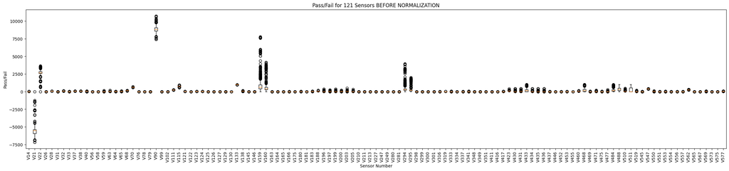

```python
x = semi_sensors.iloc[:, 1:]   # Select all columns except the first one (Pass/Fail)
y = semi_sensors['Pass/Fail']  # Select the Pass/Fail column

# Create the boxplot
fig, ax = plt.subplots(figsize=(30, 6))
ax.boxplot(x.values, labels=x.columns)
ax.set_title('Pass/Fail for 121 Sensors BEFORE NORMALIZATION')
ax.set_ylabel('Pass/Fail')
ax.set_xlabel('Sensor Number')
plt.xticks(rotation=90)
plt.show()
```

**USE SCALER TO NORMALIZE SELECTED FEATURES**

```python
from sklearn.preprocessing import RobustScaler
```

```python
X = semi_sensors.drop('Pass/Fail', axis=1)
y = semi_sensors['Pass/Fail']
```

```python
scaler = RobustScaler()
scaler.fit(X)
```

```
RobustScaler()
```

```python
X_scaled = scaler.transform(X)
```

```python
X_scaled_df = pd.DataFrame(X_scaled, columns=X.columns)
semi_sensors_scaled = pd.concat([y, X_scaled_df], axis=1)
```

```python
semi_sensors_scaled.head()
```

|  | Pass/Fail | V14 | V21 | V22 | V26 | V28 | V31 | V32 | V33 | V37 | ... | V554 | V556 | V557 | V562 | V565 | V567 | V569 | V573 | V575 | V577 |
| --- | --- | --- | --- | --- | --- | --- | --- | --- | --- | --- | --- | --- | --- | --- | --- | --- | --- | --- | --- | --- | --- |
| 0 | 0 | -0.270631 | 0.180990 | 0.961905 | -2.211509 | -1.010283 | 0.513466 | -1.393080 | 1.545152 | 0.273615 | ... | -1.055550 | -1.041011 | -1.003331 | -0.585987 | 0.035496 | 0.089846 | 0.123566 | 0.178901 | 0.353576 | 0.203070 |
| 1 | 0 | 0.313906 | 0.141927 | -0.227619 | 0.290306 | -0.150527 | -0.083724 | -0.187949 | 2.142530 | -4.341108 | ... | -0.030006 | -0.332661 | 0.268566 | -0.585987 | 0.035496 | 0.089846 | 0.123566 | -0.225431 | -0.331984 | -0.522928 |
| 2 | 1 | 0.144021 | 0.131076 | 0.143810 | 0.447900 | -0.415069 | 0.978923 | -0.306457 | -0.230961 | -1.298594 | ... | -0.810202 | -0.314327 | -0.819192 | 1.060790 | 6.053064 | 6.648829 | 6.429713 | -0.843963 | -0.688259 | -0.814754 |
| 3 | 0 | 0.167812 | 0.095486 | -0.060000 | 0.181441 | -1.277103 | -0.293326 | -0.183714 | -0.189555 | -3.428619 | ... | 107.060502 | 34.147110 | 89.057541 | 1.503040 | 0.255212 | 0.321070 | 0.641287 | -0.959487 | -0.998650 | -0.938245 |
| 4 | 0 | 0.423238 | 0.081597 | -0.109524 | 0.050804 | -1.297627 | -0.928571 | 0.948138 | -0.004786 | -0.255418 | ... | 2.065232 | 0.759396 | 1.485171 | -0.585987 | 0.035496 | 0.089846 | 0.123566 | -0.569595 | -0.510121 | -0.510472 |

5 rows × 122 columns

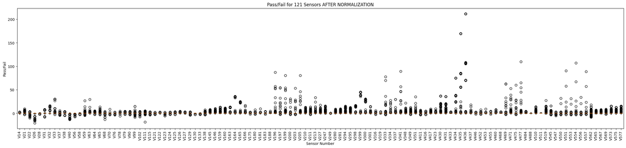

```python
x = semi_sensors_scaled.iloc[:, 1:]   # Select all columns except the first one (Pass/Fail)
y = semi_sensors_scaled['Pass/Fail']  # Select the Pass/Fail column

# Create the boxplot
fig, ax = plt.subplots(figsize=(30, 6))
ax.boxplot(x.values, labels=x.columns)
ax.set_title('Pass/Fail for 121 Sensors AFTER NORMALIZATION')
ax.set_ylabel('Pass/Fail')
ax.set_xlabel('Sensor Number')
plt.xticks(rotation=90)
plt.show()
```